# Risk Factor Analysis

## Outcome Variable

**Outcome Variable:** ever_stunted

## Predictor Variables

**Intervention Variable:** brthmon

**Adjustment Set:**

unadjusted

## Stratifying Variables

The analysis was stratified on these variable(s):

- agecat
- studyid
- country

## Data Summary

| agecat | studyid | country | brthmon | ever_stunted | n_cell | n |
| --- | --- | --- | --- | --- | --- | --- |
| 0-24 months | CMC-V-BCS-2002 | INDIA | 1 | 0 | 3 | 373 |
| 0-24 months | CMC-V-BCS-2002 | INDIA | 1 | 1 | 31 | 373 |
| 0-24 months | CMC-V-BCS-2002 | INDIA | 2 | 0 | 1 | 373 |
| 0-24 months | CMC-V-BCS-2002 | INDIA | 2 | 1 | 15 | 373 |
| 0-24 months | CMC-V-BCS-2002 | INDIA | 3 | 0 | 0 | 373 |
| 0-24 months | CMC-V-BCS-2002 | INDIA | 3 | 1 | 31 | 373 |
| 0-24 months | CMC-V-BCS-2002 | INDIA | 4 | 0 | 8 | 373 |
| 0-24 months | CMC-V-BCS-2002 | INDIA | 4 | 1 | 36 | 373 |
| 0-24 months | CMC-V-BCS-2002 | INDIA | 5 | 0 | 1 | 373 |
| 0-24 months | CMC-V-BCS-2002 | INDIA | 5 | 1 | 35 | 373 |
| 0-24 months | CMC-V-BCS-2002 | INDIA | 6 | 0 | 2 | 373 |
| 0-24 months | CMC-V-BCS-2002 | INDIA | 6 | 1 | 35 | 373 |
| 0-24 months | CMC-V-BCS-2002 | INDIA | 7 | 0 | 4 | 373 |
| 0-24 months | CMC-V-BCS-2002 | INDIA | 7 | 1 | 35 | 373 |
| 0-24 months | CMC-V-BCS-2002 | INDIA | 8 | 0 | 2 | 373 |
| 0-24 months | CMC-V-BCS-2002 | INDIA | 8 | 1 | 16 | 373 |
| 0-24 months | CMC-V-BCS-2002 | INDIA | 9 | 0 | 0 | 373 |
| 0-24 months | CMC-V-BCS-2002 | INDIA | 9 | 1 | 21 | 373 |
| 0-24 months | CMC-V-BCS-2002 | INDIA | 10 | 0 | 3 | 373 |
| 0-24 months | CMC-V-BCS-2002 | INDIA | 10 | 1 | 26 | 373 |
| 0-24 months | CMC-V-BCS-2002 | INDIA | 11 | 0 | 4 | 373 |
| 0-24 months | CMC-V-BCS-2002 | INDIA | 11 | 1 | 39 | 373 |
| 0-24 months | CMC-V-BCS-2002 | INDIA | 12 | 0 | 0 | 373 |
| 0-24 months | CMC-V-BCS-2002 | INDIA | 12 | 1 | 25 | 373 |
| 0-24 months | CMIN | BANGLADESH | 1 | 0 | 4 | 277 |
| 0-24 months | CMIN | BANGLADESH | 1 | 1 | 26 | 277 |
| 0-24 months | CMIN | BANGLADESH | 2 | 0 | 7 | 277 |
| 0-24 months | CMIN | BANGLADESH | 2 | 1 | 20 | 277 |
| 0-24 months | CMIN | BANGLADESH | 3 | 0 | 3 | 277 |
| 0-24 months | CMIN | BANGLADESH | 3 | 1 | 17 | 277 |

[output cut: 1890 more lines]

The following strata were considered:

- agecat: 0-24 months, studyid: CMC-V-BCS-2002, country: INDIA
- agecat: 0-24 months, studyid: CMIN, country: BANGLADESH
- agecat: 0-24 months, studyid: CONTENT, country: PERU
- agecat: 0-24 months, studyid: EE, country: PAKISTAN
- agecat: 0-24 months, studyid: GMS-Nepal, country: NEPAL
- agecat: 0-24 months, studyid: Guatemala BSC, country: GUATEMALA
- agecat: 0-24 months, studyid: iLiNS-Zinc, country: BURKINA FASO
- agecat: 0-24 months, studyid: IRC, country: INDIA
- agecat: 0-24 months, studyid: JiVitA-3, country: BANGLADESH
- agecat: 0-24 months, studyid: JiVitA-4, country: BANGLADESH
- agecat: 0-24 months, studyid: Keneba, country: GAMBIA
- agecat: 0-24 months, studyid: LCNI-5, country: MALAWI
- agecat: 0-24 months, studyid: MAL-ED, country: BANGLADESH
- agecat: 0-24 months, studyid: MAL-ED, country: BRAZIL
- agecat: 0-24 months, studyid: MAL-ED, country: INDIA
- agecat: 0-24 months, studyid: MAL-ED, country: NEPAL
- agecat: 0-24 months, studyid: MAL-ED, country: PERU
- agecat: 0-24 months, studyid: MAL-ED, country: SOUTH AFRICA
- agecat: 0-24 months, studyid: MAL-ED, country: TANZANIA, UNITED REPUBLIC OF
- agecat: 0-24 months, studyid: NIH-Birth, country: BANGLADESH
- agecat: 0-24 months, studyid: PROBIT, country: BELARUS
- agecat: 0-24 months, studyid: PROVIDE, country: BANGLADESH
- agecat: 0-24 months, studyid: ResPak, country: PAKISTAN
- agecat: 0-24 months, studyid: SAS-CompFeed, country: INDIA
- agecat: 0-24 months, studyid: SAS-FoodSuppl, country: INDIA
- agecat: 0-24 months, studyid: TanzaniaChild2, country: TANZANIA, UNITED REPUBLIC OF
- agecat: 0-24 months, studyid: ZVITAMBO, country: ZIMBABWE
- agecat: 0-6 months, studyid: CMC-V-BCS-2002, country: INDIA
- agecat: 0-6 months, studyid: CMIN, country: BANGLADESH
- agecat: 0-6 months, studyid: CONTENT, country: PERU
- agecat: 0-6 months, studyid: EE, country: PAKISTAN
- agecat: 0-6 months, studyid: GMS-Nepal, country: NEPAL
- agecat: 0-6 months, studyid: Guatemala BSC, country: GUATEMALA
- agecat: 0-6 months, studyid: IRC, country: INDIA
- agecat: 0-6 months, studyid: JiVitA-3, country: BANGLADESH
- agecat: 0-6 months, studyid: JiVitA-4, country: BANGLADESH
- agecat: 0-6 months, studyid: Keneba, country: GAMBIA
- agecat: 0-6 months, studyid: LCNI-5, country: MALAWI
- agecat: 0-6 months, studyid: MAL-ED, country: BANGLADESH
- agecat: 0-6 months, studyid: MAL-ED, country: BRAZIL
- agecat: 0-6 months, studyid: MAL-ED, country: INDIA
- agecat: 0-6 months, studyid: MAL-ED, country: NEPAL
- agecat: 0-6 months, studyid: MAL-ED, country: PERU
- agecat: 0-6 months, studyid: MAL-ED, country: SOUTH AFRICA
- agecat: 0-6 months, studyid: MAL-ED, country: TANZANIA, UNITED REPUBLIC OF
- agecat: 0-6 months, studyid: NIH-Birth, country: BANGLADESH
- agecat: 0-6 months, studyid: PROBIT, country: BELARUS
- agecat: 0-6 months, studyid: PROVIDE, country: BANGLADESH
- agecat: 0-6 months, studyid: ResPak, country: PAKISTAN
- agecat: 0-6 months, studyid: SAS-CompFeed, country: INDIA
- agecat: 0-6 months, studyid: SAS-FoodSuppl, country: INDIA
- agecat: 0-6 months, studyid: TanzaniaChild2, country: TANZANIA, UNITED REPUBLIC OF
- agecat: 0-6 months, studyid: ZVITAMBO, country: ZIMBABWE
- agecat: 6-24 months, studyid: CMC-V-BCS-2002, country: INDIA
- agecat: 6-24 months, studyid: CMIN, country: BANGLADESH
- agecat: 6-24 months, studyid: CONTENT, country: PERU
- agecat: 6-24 months, studyid: EE, country: PAKISTAN
- agecat: 6-24 months, studyid: GMS-Nepal, country: NEPAL
- agecat: 6-24 months, studyid: Guatemala BSC, country: GUATEMALA
- agecat: 6-24 months, studyid: iLiNS-Zinc, country: BURKINA FASO
- agecat: 6-24 months, studyid: IRC, country: INDIA
- agecat: 6-24 months, studyid: JiVitA-3, country: BANGLADESH
- agecat: 6-24 months, studyid: JiVitA-4, country: BANGLADESH
- agecat: 6-24 months, studyid: Keneba, country: GAMBIA
- agecat: 6-24 months, studyid: LCNI-5, country: MALAWI
- agecat: 6-24 months, studyid: MAL-ED, country: BANGLADESH
- agecat: 6-24 months, studyid: MAL-ED, country: BRAZIL
- agecat: 6-24 months, studyid: MAL-ED, country: INDIA
- agecat: 6-24 months, studyid: MAL-ED, country: NEPAL
- agecat: 6-24 months, studyid: MAL-ED, country: PERU
- agecat: 6-24 months, studyid: MAL-ED, country: SOUTH AFRICA
- agecat: 6-24 months, studyid: MAL-ED, country: TANZANIA, UNITED REPUBLIC OF
- agecat: 6-24 months, studyid: NIH-Birth, country: BANGLADESH
- agecat: 6-24 months, studyid: PROBIT, country: BELARUS
- agecat: 6-24 months, studyid: PROVIDE, country: BANGLADESH
- agecat: 6-24 months, studyid: ResPak, country: PAKISTAN
- agecat: 6-24 months, studyid: SAS-CompFeed, country: INDIA
- agecat: 6-24 months, studyid: SAS-FoodSuppl, country: INDIA
- agecat: 6-24 months, studyid: TanzaniaChild2, country: TANZANIA, UNITED REPUBLIC OF
- agecat: 6-24 months, studyid: ZVITAMBO, country: ZIMBABWE

### Dropped Strata

Some strata were dropped due to rare outcomes:

- agecat: 0-24 months, studyid: CMC-V-BCS-2002, country: INDIA
- agecat: 0-24 months, studyid: CMIN, country: BANGLADESH
- agecat: 0-24 months, studyid: CONTENT, country: PERU
- agecat: 0-24 months, studyid: EE, country: PAKISTAN
- agecat: 0-24 months, studyid: GMS-Nepal, country: NEPAL
- agecat: 0-24 months, studyid: Guatemala BSC, country: GUATEMALA
- agecat: 0-24 months, studyid: IRC, country: INDIA
- agecat: 0-24 months, studyid: JiVitA-4, country: BANGLADESH
- agecat: 0-24 months, studyid: MAL-ED, country: BRAZIL
- agecat: 0-24 months, studyid: MAL-ED, country: INDIA
- agecat: 0-24 months, studyid: MAL-ED, country: NEPAL
- agecat: 0-24 months, studyid: MAL-ED, country: TANZANIA, UNITED REPUBLIC OF
- agecat: 0-24 months, studyid: ResPak, country: PAKISTAN
- agecat: 0-24 months, studyid: SAS-FoodSuppl, country: INDIA
- agecat: 0-6 months, studyid: CMIN, country: BANGLADESH
- agecat: 0-6 months, studyid: CONTENT, country: PERU
- agecat: 0-6 months, studyid: EE, country: PAKISTAN
- agecat: 0-6 months, studyid: GMS-Nepal, country: NEPAL
- agecat: 0-6 months, studyid: Guatemala BSC, country: GUATEMALA
- agecat: 0-6 months, studyid: JiVitA-4, country: BANGLADESH
- agecat: 0-6 months, studyid: LCNI-5, country: MALAWI
- agecat: 0-6 months, studyid: MAL-ED, country: BANGLADESH
- agecat: 0-6 months, studyid: MAL-ED, country: BRAZIL
- agecat: 0-6 months, studyid: MAL-ED, country: INDIA
- agecat: 0-6 months, studyid: MAL-ED, country: NEPAL
- agecat: 0-6 months, studyid: MAL-ED, country: PERU
- agecat: 0-6 months, studyid: MAL-ED, country: SOUTH AFRICA
- agecat: 0-6 months, studyid: MAL-ED, country: TANZANIA, UNITED REPUBLIC OF
- agecat: 0-6 months, studyid: ResPak, country: PAKISTAN
- agecat: 0-6 months, studyid: SAS-FoodSuppl, country: INDIA
- agecat: 6-24 months, studyid: CMC-V-BCS-2002, country: INDIA
- agecat: 6-24 months, studyid: CMIN, country: BANGLADESH
- agecat: 6-24 months, studyid: CONTENT, country: PERU
- agecat: 6-24 months, studyid: EE, country: PAKISTAN
- agecat: 6-24 months, studyid: GMS-Nepal, country: NEPAL
- agecat: 6-24 months, studyid: Guatemala BSC, country: GUATEMALA
- agecat: 6-24 months, studyid: IRC, country: INDIA
- agecat: 6-24 months, studyid: JiVitA-4, country: BANGLADESH
- agecat: 6-24 months, studyid: MAL-ED, country: BANGLADESH
- agecat: 6-24 months, studyid: MAL-ED, country: BRAZIL
- agecat: 6-24 months, studyid: MAL-ED, country: INDIA
- agecat: 6-24 months, studyid: MAL-ED, country: NEPAL
- agecat: 6-24 months, studyid: MAL-ED, country: PERU
- agecat: 6-24 months, studyid: MAL-ED, country: SOUTH AFRICA
- agecat: 6-24 months, studyid: MAL-ED, country: TANZANIA, UNITED REPUBLIC OF
- agecat: 6-24 months, studyid: PROVIDE, country: BANGLADESH
- agecat: 6-24 months, studyid: ResPak, country: PAKISTAN
- agecat: 6-24 months, studyid: SAS-FoodSuppl, country: INDIA

## Methods Detail

We're interested in the causal parameters $E[Y_a]$ for all values of $a \in \mathcal{A}$. These parameters represent the mean outcome if, possibly contrary to fact, we intervened to set all units to have $A=a$. Under the randomization and positivity assumptions, these are identified by the statistical parameters $\psi_a=E_W[E_{Y|A,W}(Y|A=a,W)]$. In addition, we're interested in the mean of $Y$, $E[Y]$ under no intervention (the observed mean). We will estimate these parameters by using SuperLearner to fit the relevant likelihood factors -- $E_{Y|A,W}(Y|A=a,W)$ and $p(A=a|W)$, and then updating our likelihood fit using a joint TMLE.

For unadjusted analyses ($W=\{\}$), initial likelihoods were estimated using Lrnr_glm to estimate the simple $E(Y|A)$ and Lrnr_mean to estimate $p(A)$. For adjusted analyses, a small library containing Lrnr_glmnet, Lrnr_xgboost, and Lrnr_mean was used.

Having estimated these parameters, we will then use the delta method to estimate relative risks and attributable risks relative to a prespecified baseline level of $A$.

# Results Detail

## Results Plots

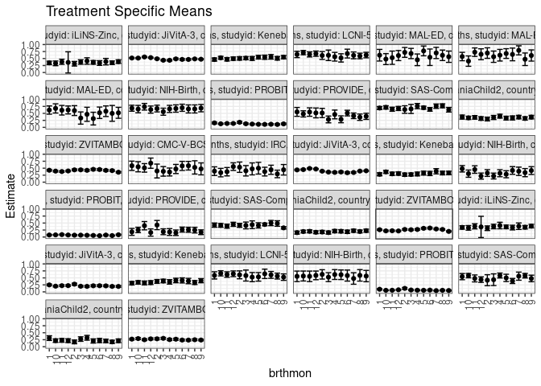

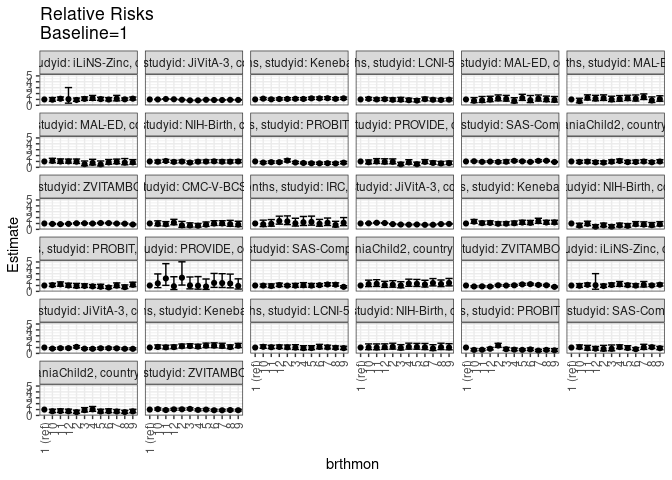

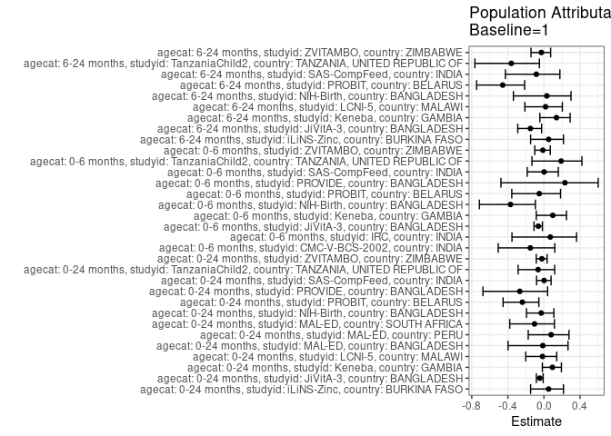

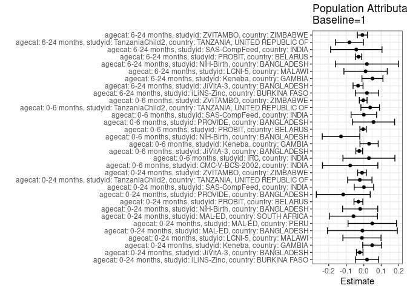

## Results Table

### Parameter: TSM

| agecat | studyid | country | intervention_level | baseline_level | estimate | ci_lower | ci_upper |
| --- | --- | --- | --- | --- | --- | --- | --- |
| 0-24 months | iLiNS-Zinc | BURKINA FASO | 1 | NA | 0.3436533 | 0.2809428 | 0.4063637 |
| 0-24 months | iLiNS-Zinc | BURKINA FASO | 2 | NA | 0.3149171 | 0.2325476 | 0.3972866 |
| 0-24 months | iLiNS-Zinc | BURKINA FASO | 3 | NA | 0.3756345 | 0.2958412 | 0.4554278 |
| 0-24 months | iLiNS-Zinc | BURKINA FASO | 4 | NA | 0.4114833 | 0.2953356 | 0.5276309 |
| 0-24 months | iLiNS-Zinc | BURKINA FASO | 5 | NA | 0.3623853 | 0.2960236 | 0.4287470 |
| 0-24 months | iLiNS-Zinc | BURKINA FASO | 6 | NA | 0.3385417 | 0.2543744 | 0.4227089 |
| 0-24 months | iLiNS-Zinc | BURKINA FASO | 7 | NA | 0.3877551 | 0.2718523 | 0.5036579 |
| 0-24 months | iLiNS-Zinc | BURKINA FASO | 8 | NA | 0.3498350 | 0.2867564 | 0.4129136 |
| 0-24 months | iLiNS-Zinc | BURKINA FASO | 9 | NA | 0.3892944 | 0.3250567 | 0.4535321 |
| 0-24 months | iLiNS-Zinc | BURKINA FASO | 10 | NA | 0.3279570 | 0.2443829 | 0.4115311 |
| 0-24 months | iLiNS-Zinc | BURKINA FASO | 11 | NA | 0.3830409 | 0.2908783 | 0.4752036 |
| 0-24 months | iLiNS-Zinc | BURKINA FASO | 12 | NA | 0.3613707 | -0.0187158 | 0.7414573 |
| 0-24 months | JiVitA-3 | BANGLADESH | 1 | NA | 0.5181245 | 0.4981549 | 0.5380941 |
| 0-24 months | JiVitA-3 | BANGLADESH | 2 | NA | 0.4900918 | 0.4675535 | 0.5126301 |
| 0-24 months | JiVitA-3 | BANGLADESH | 3 | NA | 0.4389642 | 0.4173110 | 0.4606175 |
| 0-24 months | JiVitA-3 | BANGLADESH | 4 | NA | 0.4375000 | 0.4133159 | 0.4616841 |
| 0-24 months | JiVitA-3 | BANGLADESH | 5 | NA | 0.4867925 | 0.4577093 | 0.5158756 |
| 0-24 months | JiVitA-3 | BANGLADESH | 6 | NA | 0.4689507 | 0.4398750 | 0.4980265 |
| 0-24 months | JiVitA-3 | BANGLADESH | 7 | NA | 0.4673016 | 0.4405913 | 0.4940118 |
| 0-24 months | JiVitA-3 | BANGLADESH | 8 | NA | 0.4860724 | 0.4635936 | 0.5085512 |
| 0-24 months | JiVitA-3 | BANGLADESH | 9 | NA | 0.4751697 | 0.4546546 | 0.4956848 |
| 0-24 months | JiVitA-3 | BANGLADESH | 10 | NA | 0.5156724 | 0.4953343 | 0.5360104 |
| 0-24 months | JiVitA-3 | BANGLADESH | 11 | NA | 0.5560656 | 0.5372113 | 0.5749198 |
| 0-24 months | JiVitA-3 | BANGLADESH | 12 | NA | 0.5321656 | 0.5134239 | 0.5509073 |
| 0-24 months | Keneba | GAMBIA | 1 | NA | 0.4644068 | 0.4074850 | 0.5213286 |
| 0-24 months | Keneba | GAMBIA | 2 | NA | 0.5039062 | 0.4426487 | 0.5651638 |
| 0-24 months | Keneba | GAMBIA | 3 | NA | 0.5130719 | 0.4570596 | 0.5690842 |
| 0-24 months | Keneba | GAMBIA | 4 | NA | 0.5025381 | 0.4327062 | 0.5723700 |
| 0-24 months | Keneba | GAMBIA | 5 | NA | 0.5490196 | 0.4807260 | 0.6173132 |
| 0-24 months | Keneba | GAMBIA | 6 | NA | 0.5460123 | 0.4695667 | 0.6224578 |

[output cut: 354 more lines]

### Parameter: E(Y)

| agecat | studyid | country | intervention_level | baseline_level | estimate | ci_lower | ci_upper |
| --- | --- | --- | --- | --- | --- | --- | --- |
| 0-24 months | iLiNS-Zinc | BURKINA FASO | NA | NA | 0.3623277 | 0.3130786 | 0.4115769 |
| 0-24 months | JiVitA-3 | BANGLADESH | NA | NA | 0.4953171 | 0.4874955 | 0.5031388 |
| 0-24 months | Keneba | GAMBIA | NA | NA | 0.5125214 | 0.4943731 | 0.5306698 |
| 0-24 months | LCNI-5 | MALAWI | NA | NA | 0.6369048 | 0.6043650 | 0.6694445 |
| 0-24 months | MAL-ED | BANGLADESH | NA | NA | 0.6113208 | 0.5525209 | 0.6701206 |
| 0-24 months | MAL-ED | PERU | NA | NA | 0.6204620 | 0.5657315 | 0.6751926 |
| 0-24 months | MAL-ED | SOUTH AFRICA | NA | NA | 0.5605096 | 0.5055248 | 0.6154943 |
| 0-24 months | NIH-Birth | BANGLADESH | NA | NA | 0.6645469 | 0.6276196 | 0.7014742 |
| 0-24 months | PROBIT | BELARUS | NA | NA | 0.1274191 | 0.1115552 | 0.1432829 |
| 0-24 months | PROVIDE | BANGLADESH | NA | NA | 0.4357143 | 0.3989556 | 0.4724730 |
| 0-24 months | SAS-CompFeed | INDIA | NA | NA | 0.6914547 | 0.6510509 | 0.7318584 |
| 0-24 months | TanzaniaChild2 | TANZANIA, UNITED REPUBLIC OF | NA | NA | 0.3459933 | 0.3269422 | 0.3650444 |
| 0-24 months | ZVITAMBO | ZIMBABWE | NA | NA | 0.4171522 | 0.4090055 | 0.4252989 |
| 0-6 months | CMC-V-BCS-2002 | INDIA | NA | NA | 0.5108696 | 0.4597270 | 0.5620121 |
| 0-6 months | IRC | INDIA | NA | NA | 0.4243902 | 0.3764905 | 0.4722900 |
| 0-6 months | JiVitA-3 | BANGLADESH | NA | NA | 0.4129818 | 0.4055453 | 0.4204184 |
| 0-6 months | Keneba | GAMBIA | NA | NA | 0.3123732 | 0.2940736 | 0.3306728 |
| 0-6 months | NIH-Birth | BANGLADESH | NA | NA | 0.3497615 | 0.3124631 | 0.3870600 |
| 0-6 months | PROBIT | BELARUS | NA | NA | 0.0686124 | 0.0577768 | 0.0794479 |
| 0-6 months | PROVIDE | BANGLADESH | NA | NA | 0.2400000 | 0.2083392 | 0.2716608 |
| 0-6 months | SAS-CompFeed | INDIA | NA | NA | 0.4254902 | 0.3977202 | 0.4532601 |
| 0-6 months | TanzaniaChild2 | TANZANIA, UNITED REPUBLIC OF | NA | NA | 0.1949082 | 0.1790434 | 0.2107729 |
| 0-6 months | ZVITAMBO | ZIMBABWE | NA | NA | 0.2586612 | 0.2514220 | 0.2659004 |
| 6-24 months | iLiNS-Zinc | BURKINA FASO | NA | NA | 0.3623277 | 0.3130786 | 0.4115769 |
| 6-24 months | JiVitA-3 | BANGLADESH | NA | NA | 0.2162394 | 0.2068628 | 0.2256160 |
| 6-24 months | Keneba | GAMBIA | NA | NA | 0.3589489 | 0.3380095 | 0.3798884 |
| 6-24 months | LCNI-5 | MALAWI | NA | NA | 0.6000000 | 0.5644377 | 0.6355623 |
| 6-24 months | NIH-Birth | BANGLADESH | NA | NA | 0.5739130 | 0.5216565 | 0.6261696 |
| 6-24 months | PROBIT | BELARUS | NA | NA | 0.0642659 | 0.0526827 | 0.0758490 |
| 6-24 months | SAS-CompFeed | INDIA | NA | NA | 0.5030750 | 0.4588491 | 0.5473009 |
| 6-24 months | TanzaniaChild2 | TANZANIA, UNITED REPUBLIC OF | NA | NA | 0.2259675 | 0.2054816 | 0.2464534 |
| 6-24 months | ZVITAMBO | ZIMBABWE | NA | NA | 0.2630340 | 0.2536720 | 0.2723961 |

### Parameter: RR

| agecat | studyid | country | intervention_level | baseline_level | estimate | ci_lower | ci_upper |
| --- | --- | --- | --- | --- | --- | --- | --- |
| 0-24 months | iLiNS-Zinc | BURKINA FASO | 1 | 1 | 1.0000000 | 1.0000000 | 1.0000000 |
| 0-24 months | iLiNS-Zinc | BURKINA FASO | 2 | 1 | 0.9163805 | 0.6815717 | 1.2320834 |
| 0-24 months | iLiNS-Zinc | BURKINA FASO | 3 | 1 | 1.0930626 | 0.8343733 | 1.4319560 |
| 0-24 months | iLiNS-Zinc | BURKINA FASO | 4 | 1 | 1.1973792 | 0.8532016 | 1.6803964 |
| 0-24 months | iLiNS-Zinc | BURKINA FASO | 5 | 1 | 1.0545086 | 0.8141899 | 1.3657605 |
| 0-24 months | iLiNS-Zinc | BURKINA FASO | 6 | 1 | 0.9851258 | 0.7469710 | 1.2992108 |
| 0-24 months | iLiNS-Zinc | BURKINA FASO | 7 | 1 | 1.1283324 | 0.7561694 | 1.6836624 |
| 0-24 months | iLiNS-Zinc | BURKINA FASO | 8 | 1 | 1.0179883 | 0.8294685 | 1.2493544 |
| 0-24 months | iLiNS-Zinc | BURKINA FASO | 9 | 1 | 1.1328116 | 0.9130221 | 1.4055105 |
| 0-24 months | iLiNS-Zinc | BURKINA FASO | 10 | 1 | 0.9543253 | 0.6902449 | 1.3194401 |
| 0-24 months | iLiNS-Zinc | BURKINA FASO | 11 | 1 | 1.1146146 | 0.8768254 | 1.4168908 |
| 0-24 months | iLiNS-Zinc | BURKINA FASO | 12 | 1 | 1.0515562 | 0.3663461 | 3.0183765 |
| 0-24 months | JiVitA-3 | BANGLADESH | 1 | 1 | 1.0000000 | 1.0000000 | 1.0000000 |
| 0-24 months | JiVitA-3 | BANGLADESH | 2 | 1 | 0.9458959 | 0.8897167 | 1.0056224 |
| 0-24 months | JiVitA-3 | BANGLADESH | 3 | 1 | 0.8472177 | 0.7974556 | 0.9000849 |
| 0-24 months | JiVitA-3 | BANGLADESH | 4 | 1 | 0.8443916 | 0.7906213 | 0.9018189 |
| 0-24 months | JiVitA-3 | BANGLADESH | 5 | 1 | 0.9395279 | 0.8756258 | 1.0080936 |
| 0-24 months | JiVitA-3 | BANGLADESH | 6 | 1 | 0.9050928 | 0.8424066 | 0.9724437 |
| 0-24 months | JiVitA-3 | BANGLADESH | 7 | 1 | 0.9019098 | 0.8430224 | 0.9649107 |
| 0-24 months | JiVitA-3 | BANGLADESH | 8 | 1 | 0.9381383 | 0.8839877 | 0.9956059 |
| 0-24 months | JiVitA-3 | BANGLADESH | 9 | 1 | 0.9170956 | 0.8673750 | 0.9696663 |
| 0-24 months | JiVitA-3 | BANGLADESH | 10 | 1 | 0.9952673 | 0.9445325 | 1.0487274 |
| 0-24 months | JiVitA-3 | BANGLADESH | 11 | 1 | 1.0732277 | 1.0215945 | 1.1274705 |
| 0-24 months | JiVitA-3 | BANGLADESH | 12 | 1 | 1.0270999 | 0.9769399 | 1.0798352 |
| 0-24 months | Keneba | GAMBIA | 1 | 1 | 1.0000000 | 1.0000000 | 1.0000000 |
| 0-24 months | Keneba | GAMBIA | 2 | 1 | 1.0850536 | 0.9130169 | 1.2895067 |
| 0-24 months | Keneba | GAMBIA | 3 | 1 | 1.1047898 | 0.9375521 | 1.3018589 |
| 0-24 months | Keneba | GAMBIA | 4 | 1 | 1.0821075 | 0.8990830 | 1.3023900 |
| 0-24 months | Keneba | GAMBIA | 5 | 1 | 1.1821955 | 0.9927672 | 1.4077683 |
| 0-24 months | Keneba | GAMBIA | 6 | 1 | 1.1757199 | 0.9760929 | 1.4161737 |

[output cut: 354 more lines]

### Parameter: PAR

| agecat | studyid | country | intervention_level | baseline_level | estimate | ci_lower | ci_upper |
| --- | --- | --- | --- | --- | --- | --- | --- |
| 0-24 months | iLiNS-Zinc | BURKINA FASO | 1 | NA | 0.0186745 | -0.0479956 | 0.0853445 |
| 0-24 months | JiVitA-3 | BANGLADESH | 1 | NA | -0.0228074 | -0.0413883 | -0.0042264 |
| 0-24 months | Keneba | GAMBIA | 1 | NA | 0.0481147 | -0.0058636 | 0.1020929 |
| 0-24 months | LCNI-5 | MALAWI | 1 | NA | -0.0101541 | -0.1191689 | 0.0988608 |
| 0-24 months | MAL-ED | BANGLADESH | 1 | NA | -0.0077269 | -0.2074690 | 0.1920153 |
| 0-24 months | MAL-ED | PERU | 1 | NA | 0.0490335 | -0.0896696 | 0.1877366 |
| 0-24 months | MAL-ED | SOUTH AFRICA | 1 | NA | -0.0585381 | -0.1959177 | 0.0788416 |
| 0-24 months | NIH-Birth | BANGLADESH | 1 | NA | -0.0203846 | -0.1208715 | 0.0801023 |
| 0-24 months | PROBIT | BELARUS | 1 | NA | -0.0304757 | -0.0557394 | -0.0052119 |
| 0-24 months | PROVIDE | BANGLADESH | 1 | NA | -0.1169173 | -0.2707429 | 0.0369083 |
| 0-24 months | SAS-CompFeed | INDIA | 1 | NA | 0.0011892 | -0.0543226 | 0.0567009 |
| 0-24 months | TanzaniaChild2 | TANZANIA, UNITED REPUBLIC OF | 1 | NA | -0.0224277 | -0.0920404 | 0.0471850 |
| 0-24 months | ZVITAMBO | ZIMBABWE | 1 | NA | -0.0098471 | -0.0347954 | 0.0151013 |
| 0-6 months | CMC-V-BCS-2002 | INDIA | 1 | NA | -0.0773657 | -0.2354350 | 0.0807036 |
| 0-6 months | IRC | INDIA | 1 | NA | 0.0296534 | -0.1187314 | 0.1780382 |
| 0-6 months | JiVitA-3 | BANGLADESH | 1 | NA | -0.0258017 | -0.0449660 | -0.0066375 |
| 0-6 months | Keneba | GAMBIA | 1 | NA | 0.0305199 | -0.0215100 | 0.0825498 |
| 0-6 months | NIH-Birth | BANGLADESH | 1 | NA | -0.1296905 | -0.2368923 | -0.0224887 |
| 0-6 months | PROBIT | BELARUS | 1 | NA | -0.0035828 | -0.0218077 | 0.0146422 |
| 0-6 months | PROVIDE | BANGLADESH | 1 | NA | 0.0557895 | -0.0648922 | 0.1764711 |
| 0-6 months | SAS-CompFeed | INDIA | 1 | NA | 0.0007114 | -0.0722036 | 0.0736264 |
| 0-6 months | TanzaniaChild2 | TANZANIA, UNITED REPUBLIC OF | 1 | NA | 0.0370134 | -0.0160280 | 0.0900549 |
| 0-6 months | ZVITAMBO | ZIMBABWE | 1 | NA | -0.0031035 | -0.0252994 | 0.0190923 |
| 6-24 months | iLiNS-Zinc | BURKINA FASO | 1 | NA | 0.0186745 | -0.0479956 | 0.0853445 |
| 6-24 months | JiVitA-3 | BANGLADESH | 1 | NA | -0.0325411 | -0.0610298 | -0.0040524 |
| 6-24 months | Keneba | GAMBIA | 1 | NA | 0.0497702 | -0.0101477 | 0.1096881 |
| 6-24 months | LCNI-5 | MALAWI | 1 | NA | 0.0107143 | -0.1131374 | 0.1345660 |
| 6-24 months | NIH-Birth | BANGLADESH | 1 | NA | 0.0183575 | -0.1617764 | 0.1984914 |
| 6-24 months | PROBIT | BELARUS | 1 | NA | -0.0293512 | -0.0470813 | -0.0116211 |
| 6-24 months | SAS-CompFeed | INDIA | 1 | NA | -0.0423795 | -0.1892117 | 0.1044527 |
| 6-24 months | TanzaniaChild2 | TANZANIA, UNITED REPUBLIC OF | 1 | NA | -0.0817248 | -0.1616986 | -0.0017509 |
| 6-24 months | ZVITAMBO | ZIMBABWE | 1 | NA | -0.0076247 | -0.0362150 | 0.0209656 |

### Parameter: PAF

| agecat | studyid | country | intervention_level | baseline_level | estimate | ci_lower | ci_upper |
| --- | --- | --- | --- | --- | --- | --- | --- |
| 0-24 months | iLiNS-Zinc | BURKINA FASO | 1 | NA | 0.0515403 | -0.1478583 | 0.2163006 |
| 0-24 months | JiVitA-3 | BANGLADESH | 1 | NA | -0.0460460 | -0.0842670 | -0.0091722 |
| 0-24 months | Keneba | GAMBIA | 1 | NA | 0.0938783 | -0.0178589 | 0.1933494 |
| 0-24 months | LCNI-5 | MALAWI | 1 | NA | -0.0159428 | -0.2023759 | 0.1415830 |
| 0-24 months | MAL-ED | BANGLADESH | 1 | NA | -0.0126396 | -0.3982560 | 0.2666300 |
| 0-24 months | MAL-ED | PERU | 1 | NA | 0.0790274 | -0.1742653 | 0.2776840 |
| 0-24 months | MAL-ED | SOUTH AFRICA | 1 | NA | -0.1044372 | -0.3793452 | 0.1156807 |
| 0-24 months | NIH-Birth | BANGLADESH | 1 | NA | -0.0306744 | -0.1935750 | 0.1099932 |
| 0-24 months | PROBIT | BELARUS | 1 | NA | -0.2391767 | -0.4533775 | -0.0565451 |
| 0-24 months | PROVIDE | BANGLADESH | 1 | NA | -0.2683348 | -0.6763250 | 0.0403573 |
| 0-24 months | SAS-CompFeed | INDIA | 1 | NA | 0.0017198 | -0.0818385 | 0.0788244 |
| 0-24 months | TanzaniaChild2 | TANZANIA, UNITED REPUBLIC OF | 1 | NA | -0.0648213 | -0.2862866 | 0.1185135 |
| 0-24 months | ZVITAMBO | ZIMBABWE | 1 | NA | -0.0236055 | -0.0851944 | 0.0344880 |
| 0-6 months | CMC-V-BCS-2002 | INDIA | 1 | NA | -0.1514393 | -0.5070942 | 0.1202856 |
| 0-6 months | IRC | INDIA | 1 | NA | 0.0698730 | -0.3546046 | 0.3613367 |
| 0-6 months | JiVitA-3 | BANGLADESH | 1 | NA | -0.0624766 | -0.1099481 | -0.0170355 |
| 0-6 months | Keneba | GAMBIA | 1 | NA | 0.0977035 | -0.0852035 | 0.2497822 |
| 0-6 months | NIH-Birth | BANGLADESH | 1 | NA | -0.3707970 | -0.7157773 | -0.0951797 |
| 0-6 months | PROBIT | BELARUS | 1 | NA | -0.0522174 | -0.3564637 | 0.1837883 |
| 0-6 months | PROVIDE | BANGLADESH | 1 | NA | 0.2324561 | -0.4768940 | 0.6011064 |
| 0-6 months | SAS-CompFeed | INDIA | 1 | NA | 0.0016720 | -0.1852750 | 0.1591329 |
| 0-6 months | TanzaniaChild2 | TANZANIA, UNITED REPUBLIC OF | 1 | NA | 0.1899019 | -0.1331480 | 0.4208534 |
| 0-6 months | ZVITAMBO | ZIMBABWE | 1 | NA | -0.0119985 | -0.1015520 | 0.0702745 |
| 6-24 months | iLiNS-Zinc | BURKINA FASO | 1 | NA | 0.0515403 | -0.1478583 | 0.2163006 |
| 6-24 months | JiVitA-3 | BANGLADESH | 1 | NA | -0.1504864 | -0.2901388 | -0.0259508 |
| 6-24 months | Keneba | GAMBIA | 1 | NA | 0.1386554 | -0.0455346 | 0.2903969 |
| 6-24 months | LCNI-5 | MALAWI | 1 | NA | 0.0178571 | -0.2118637 | 0.2040321 |
| 6-24 months | NIH-Birth | BANGLADESH | 1 | NA | 0.0319865 | -0.3387739 | 0.3000685 |
| 6-24 months | PROBIT | BELARUS | 1 | NA | -0.4567148 | -0.7468191 | -0.2147897 |
| 6-24 months | SAS-CompFeed | INDIA | 1 | NA | -0.0842409 | -0.4276894 | 0.1765867 |
| 6-24 months | TanzaniaChild2 | TANZANIA, UNITED REPUBLIC OF | 1 | NA | -0.3616660 | -0.7654315 | -0.0502442 |
| 6-24 months | ZVITAMBO | ZIMBABWE | 1 | NA | -0.0289874 | -0.1436286 | 0.0741618 |